# NDH802 - Regression

Chapter 11 and 12

> *We assign the computation to computers—our tasks are to think, analyze, and make recommendations*" (Newbold, 2016, p. 429).

## 11.5

We fit the linear regression

$y = b_0 + b_1x$

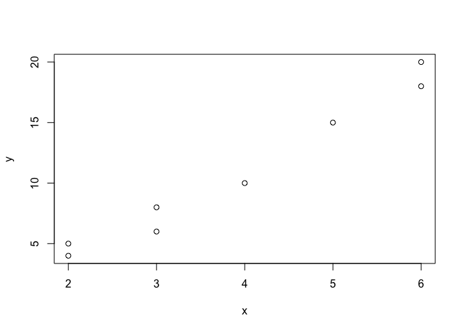

```r
#data input
x = c(2,4,3,6,3,5,6,2)
y = c(5,10,8,18,6,15,20,4)

#a. scatter plot
plot(x, y)
```

```r
#b. calculating the regression coefficients by the book.
b1 = cov(x, y)/(sd(x)^2)
b0 = mean(y) - b1 * mean(x)

#b. calculating the regression coefficients with R shortcut
mod = lm(y ~ x)
summary(mod)
```

```
##
## Call:
## lm(formula = y ~ x)
##
## Residuals:
##     Min      1Q  Median      3Q     Max
## -1.5166 -0.7550  0.1358  0.6573  1.3974
##
## Coefficients:
##             Estimate Std. Error t value Pr(>|t|)
## (Intercept)  -3.5695     1.0903  -3.274    0.017 *
## x             3.6954     0.2616  14.128 7.85e-06 ***
## ---
## Signif. codes:  0 '***' 0.001 '**' 0.01 '*' 0.05 '.' 0.1 ' ' 1
##
## Residual standard error: 1.136 on 6 degrees of freedom
## Multiple R-squared:  0.9708, Adjusted R-squared:  0.966
## F-statistic: 199.6 on 1 and 6 DF,  p-value: 7.854e-06
```

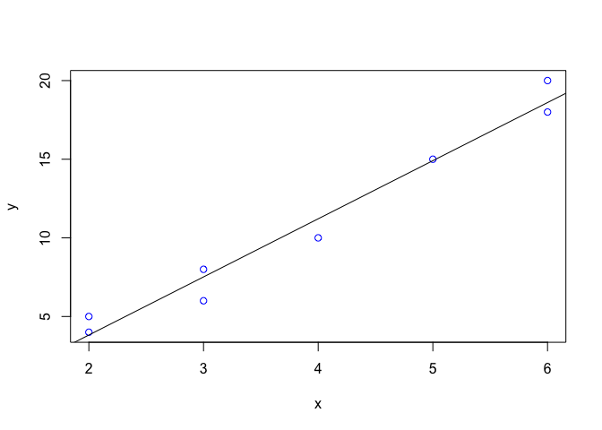

```r
#for fun, we plot the line
plot(x, y, col = "blue"); abline(mod)
```

For learning purpose, we can try calculating some of the components by hand using the formula provided in the lecture slides. `lm()` automatically calculates and report them in the model summary.

```r
SSE = sum(mod$residuals^2)
SST=sum((y-mean(y))^2)
n = length(y)
df = mod$df.residual

Residuals = summary(mod$residuals)
Residual_SE = sqrt(SSE/mod$df.residual)
R_squared = 1-SSE/SST
Adjusted_R_squared = 1-(SSE/SST)*(n-1)/df
```

For interpretation of b0 and b1, please refer to the last video on this [page.](https://sse.instructure.com/courses/425/pages/may-17-regression?module_item_id=6183)

#### Prediction

After fitting the model, we can write it as:

$y = -3.5695 + 3.6954*x$

Prediction (in this course) is simply plugging in the new x to the model to find the new y.

```r
#the more systematic way. normally, we fit the model many times, and we may want to automatize the process like this
b0 = as.numeric(mod$coefficients[1])
b1 = as.numeric(mod$coefficients[2])

#the simplier way, you copy an paste it from the summary(mod)
b0 = -3.5695
b1 = 3.6954

#For example, we have a new x = 5
newx = 5
#We plug the new x in the model
yPred = b0 + b1 * newx
```

## 11.97

Data description:

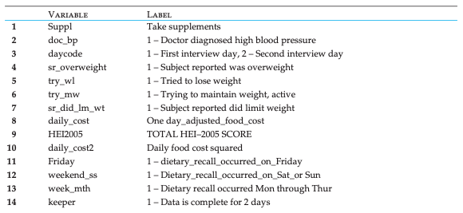

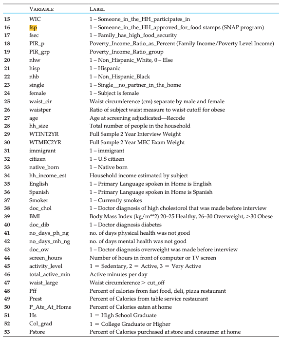

To investigate the relationship between the HEI score and the daily cost, we estimate this linear model:

$HEI = b_0 + b_1*DailyCost$

```r
#data prep
hei <- read.csv("https://raw.githubusercontent.com/lanhuongnguyen276/NDH802/master/Exercises/HEI.csv")[, -1]

x1 = hei[hei$daycode == 1, "daily_cost"] #daily cost, first interview
y1 = hei[hei$daycode == 1, "HEI2005"] #HEI score, first interview
x2 = hei[hei$daycode == 2, "daily_cost"] #daily cost, second interview
y2 = hei[hei$daycode == 2, "HEI2005"] #HEI score, second interview

#Build the regression based on the first interview data
mod1 = lm(y1 ~ x1)
summary(mod1)
```

```
##
## Call:
## lm(formula = y1 ~ x1)
##
## Residuals:
##     Min      1Q  Median      3Q     Max
## -41.606 -10.911  -0.414   9.929  46.922
##
## Coefficients:
##             Estimate Std. Error t value Pr(>|t|)
## (Intercept)  52.8977     0.4195 126.093   <2e-16 ***
## x1           -0.1701     0.0693  -2.454   0.0142 *
## ---
## Signif. codes:  0 '***' 0.001 '**' 0.01 '*' 0.05 '.' 0.1 ' ' 1
##
## Residual standard error: 14.19 on 4458 degrees of freedom
## Multiple R-squared:  0.001349,   Adjusted R-squared:  0.001125
## F-statistic: 6.023 on 1 and 4458 DF,  p-value: 0.01416
```

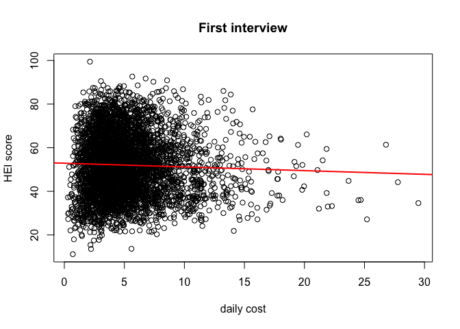

```r
#plot the data with the fitted line
plot(x1, y1, xlab = "daily cost", ylab = "HEI score", main = "First interview"); abline(mod1, col = "red", lwd = 2)
```

```r
#Build the regression based on the second interview data
mod2 = lm(y2 ~ x2)
summary(mod2)
```

```
##
## Call:
## lm(formula = y2 ~ x2)
##
## Residuals:
##     Min      1Q  Median      3Q     Max
## -41.437 -11.085   0.177  10.526  39.580
##
## Coefficients:
##             Estimate Std. Error t value Pr(>|t|)
## (Intercept) 54.75101    0.45090 121.427   <2e-16 ***
## x2          -0.07586    0.07786  -0.974     0.33
## ---
## Signif. codes:  0 '***' 0.001 '**' 0.01 '*' 0.05 '.' 0.1 ' ' 1
##
## Residual standard error: 14.56 on 4128 degrees of freedom
## Multiple R-squared:  0.0002299,  Adjusted R-squared:  -1.229e-05
## F-statistic: 0.9493 on 1 and 4128 DF,  p-value: 0.33
```

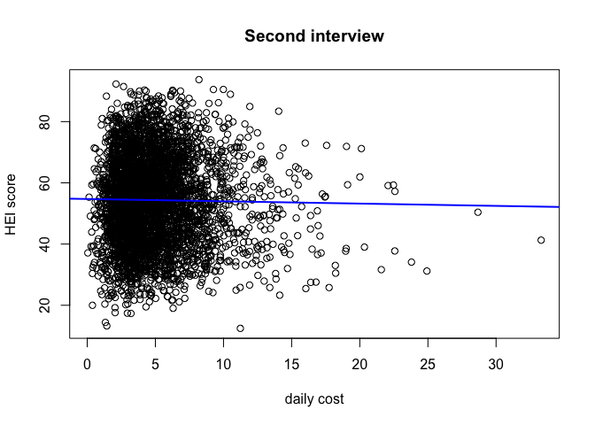

```r
#plot the data with the fitted line
plot(x2, y2, xlab = "daily cost", ylab = "HEI score", main = "Second interview"); abline(mod2, col = "blue", lwd = 2)
```

Alternatively, we can do as follows. Please understand that it is just another way of coding, not thinking. The best way is the way you feel most comfortable with.

```r
#afterloading the data, we go straight into fitting the model.
mod1.1 = lm(hei[hei$daycode == 1, "HEI2005"] ~ hei[hei$daycode == 1, "daily_cost"],
            data = hei)
mod2.1 = lm(hei[hei$daycode == 2, "HEI2005"] ~ hei[hei$daycode == 2, "daily_cost"],
            data = hei)
```

## 12.114

This is the example we did in class (which is not part of the question from the book).

$HEI = b_0 + b_1*female + b_2*age$

```r
mod_ex = lm(HEI2005 ~ female + age, data = hei)
summary(mod_ex)
```

```
##
## Call:
## lm(formula = HEI2005 ~ female + age, data = hei)
##
## Residuals:
##     Min      1Q  Median      3Q     Max
## -43.258 -10.567  -0.189  10.101  45.234
##
## Coefficients:
##              Estimate Std. Error t value Pr(>|t|)
## (Intercept) 43.557988   0.452236  96.317   <2e-16 ***
## female       2.940651   0.302802   9.711   <2e-16 ***
## age          0.159183   0.007767  20.494   <2e-16 ***
## ---
## Signif. codes:  0 '***' 0.001 '**' 0.01 '*' 0.05 '.' 0.1 ' ' 1
##
## Residual standard error: 14.01 on 8587 degrees of freedom
## Multiple R-squared:  0.05576,    Adjusted R-squared:  0.05554
## F-statistic: 253.5 on 2 and 8587 DF,  p-value: < 2.2e-16
```

```r
#we extract the coefficients
b0_ex = 43.557988
b1_ex = 2.940651
b2_ex = 0.159183

#In class, we take an example that we want to predict the HEI of a new person,
#who is male (0*b1_ex) and 20 years old (20*b2_ex)
yPred_ex = b0_ex + 0*b1_ex + 20*b2_ex
```

a. Here we are asked to fit the basic linear model:

$HEI = b_0 + b_1*docbp + b_2*waistper + b_3*BMI+ b_4*sroverweight + b_5*female + b_6*age + b_7*daycode$

```r
mod_a = lm(HEI2005 ~ doc_bp + waistper + BMI + sr_overweight +
          female + age + daycode, data = hei)
summary(mod_a)
```

```
##
## Call:
## lm(formula = HEI2005 ~ doc_bp + waistper + BMI + sr_overweight +
##     female + age + daycode, data = hei)
##
## Residuals:
##     Min      1Q  Median      3Q     Max
## -44.210 -10.401  -0.111  10.017  46.645
##
## Coefficients:
##                Estimate Std. Error t value Pr(>|t|)
## (Intercept)   44.843836   1.215816  36.884  < 2e-16 ***
## doc_bp        -0.733851   0.363817  -2.017  0.04372 *
## waistper      -7.149451   2.376826  -3.008  0.00264 **
## BMI            0.044658   0.061987   0.720  0.47128
## sr_overweight  0.521895   0.379878   1.374  0.16953
## female         3.640261   0.377975   9.631  < 2e-16 ***
## age            0.181604   0.009224  19.688  < 2e-16 ***
## daycode        2.333087   0.307256   7.593 3.46e-14 ***
## ---
## Signif. codes:  0 '***' 0.001 '**' 0.01 '*' 0.05 '.' 0.1 ' ' 1
##
## Residual standard error: 13.91 on 8209 degrees of freedom
##   (373 observations deleted due to missingness)
## Multiple R-squared:  0.06889,    Adjusted R-squared:  0.0681
## F-statistic: 86.77 on 7 and 8209 DF,  p-value: < 2.2e-16
```

b. We add one more IV, immigrant:

$HEI = b_0 + b_1*docbp + b_2*waistper + b_3*BMI+ b_4*sroverweight + b_5*female + b_6*age + b_7*daycode + b_8*immigrant$

```r
mod_b = lm(HEI2005 ~ doc_bp + waistper + BMI + sr_overweight +
          female + age + daycode + immigrant, data = hei)
summary(mod_b)
```

```
##
## Call:
## lm(formula = HEI2005 ~ doc_bp + waistper + BMI + sr_overweight +
##     female + age + daycode + immigrant, data = hei)
##
## Residuals:
##     Min      1Q  Median      3Q     Max
## -50.618  -9.980  -0.007   9.596  40.329
##
## Coefficients:
##                Estimate Std. Error t value Pr(>|t|)
## (Intercept)   41.689980   1.200115  34.738  < 2e-16 ***
## doc_bp        -0.351658   0.356345  -0.987   0.3237
## waistper      -4.291188   2.329117  -1.842   0.0655 .
## BMI           -0.013443   0.060695  -0.221   0.8247
## sr_overweight  0.823394   0.371831   2.214   0.0268 *
## female         3.451030   0.369773   9.333  < 2e-16 ***
## age            0.184361   0.009022  20.435  < 2e-16 ***
## daycode        2.358329   0.300487   7.848 4.75e-15 ***
## immigrant      7.377184   0.380856  19.370  < 2e-16 ***
## ---
## Signif. codes:  0 '***' 0.001 '**' 0.01 '*' 0.05 '.' 0.1 ' ' 1
##
## Residual standard error: 13.61 on 8208 degrees of freedom
##   (373 observations deleted due to missingness)
## Multiple R-squared:  0.1096, Adjusted R-squared:  0.1087
## F-statistic: 126.3 on 8 and 8208 DF,  p-value: < 2.2e-16
```

c. We add one more IV, single:

$HEI = b_0 + b_1*docbp + b_2*waistper + b_3*BMI+ b_4*sroverweight + b_5*female + b_6*age + b_7*daycode + b_8*single$

```r
mod_c = lm(HEI2005 ~ doc_bp + waistper + BMI + sr_overweight +
          female + age + daycode + single, data = hei)
summary(mod_c)
```

```
##
## Call:
## lm(formula = HEI2005 ~ doc_bp + waistper + BMI + sr_overweight +
##     female + age + daycode + single, data = hei)
##
## Residuals:
##     Min      1Q  Median      3Q     Max
## -45.196 -10.418  -0.213  10.056  45.953
##
## Coefficients:
##                Estimate Std. Error t value Pr(>|t|)
## (Intercept)   45.733634   1.217406  37.566  < 2e-16 ***
## doc_bp        -0.653824   0.362774  -1.802  0.07154 .
## waistper      -7.692161   2.370105  -3.245  0.00118 **
## BMI            0.069100   0.061872   1.117  0.26411
## sr_overweight  0.146278   0.381712   0.383  0.70157
## female         4.017949   0.380278  10.566  < 2e-16 ***
## age            0.180269   0.009194  19.607  < 2e-16 ***
## daycode        2.305854   0.306253   7.529 5.65e-14 ***
## single        -2.403023   0.319660  -7.517 6.18e-14 ***
## ---
## Signif. codes:  0 '***' 0.001 '**' 0.01 '*' 0.05 '.' 0.1 ' ' 1
##
## Residual standard error: 13.87 on 8206 degrees of freedom
##   (375 observations deleted due to missingness)
## Multiple R-squared:  0.07522,    Adjusted R-squared:  0.07432
## F-statistic: 83.43 on 8 and 8206 DF,  p-value: < 2.2e-16
```

c. We add one more IV, fsp:

$HEI = b_0 + b_1*docbp + b_2*waistper + b_3*BMI+ b_4*sroverweight + b_5*female + b_6*age + b_7*daycode + b_8*fsp$

```r
mod_d = lm(HEI2005 ~ doc_bp + waistper + BMI + sr_overweight +
          female + age + daycode + fsp, data = hei)
summary(mod_d)
```

```
##
## Call:
## lm(formula = HEI2005 ~ doc_bp + waistper + BMI + sr_overweight +
##     female + age + daycode + fsp, data = hei)
##
## Residuals:
##     Min      1Q  Median      3Q     Max
## -44.540 -10.432  -0.057   9.854  46.439
##
## Coefficients:
##                Estimate Std. Error t value Pr(>|t|)
## (Intercept)   44.985535   1.218010  36.934  < 2e-16 ***
## doc_bp        -0.706407   0.364213  -1.940   0.0525 .
## waistper      -6.288221   2.381526  -2.640   0.0083 **
## BMI            0.046995   0.062002   0.758   0.4485
## sr_overweight  0.259779   0.381574   0.681   0.4960
## female         3.698448   0.378912   9.761  < 2e-16 ***
## age            0.171463   0.009334  18.369  < 2e-16 ***
## daycode        2.295252   0.307859   7.456 9.87e-14 ***
## fsp           -3.506376   0.471622  -7.435 1.15e-13 ***
## ---
## Signif. codes:  0 '***' 0.001 '**' 0.01 '*' 0.05 '.' 0.1 ' ' 1
##
## Residual standard error: 13.85 on 8105 degrees of freedom
##   (476 observations deleted due to missingness)
## Multiple R-squared:  0.07448,    Adjusted R-squared:  0.07357
## F-statistic: 81.53 on 8 and 8105 DF,  p-value: < 2.2e-16
```

## 12.107

Data description:

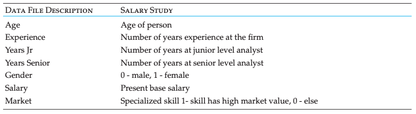

```r
#data prep
salary <- read.csv("https://raw.githubusercontent.com/lanhuongnguyen276/NDH802/master/Exercises/Salary_Study.csv")[, -1]

#It is important to learn what we should include in the model
#It is equally important to learn what we should NOT include in the model

#we may not want to include the IVs that are highly correlated (multicollinearity)
#for example, age and Experience
cor(salary)
```

```
##                     age Experience   Years.Jr Years.Senior      Gender
## age           1.0000000  0.8768846  0.7117429   0.58305078 -0.23404081
## Experience    0.8768846  1.0000000  0.8026273   0.67365398 -0.37791436
## Years.Jr      0.7117429  0.8026273  1.0000000   0.31166943 -0.36662442
## Years.Senior  0.5830508  0.6736540  0.3116694   1.00000000 -0.29167452
## Gender       -0.2340408 -0.3779144 -0.3666244  -0.29167452  1.00000000
## Salary        0.7485563  0.8833377  0.6977312   0.77714162 -0.42874555
## Market       -0.1336807 -0.1497066 -0.1128198  -0.01732257  0.06168647
##                  Salary      Market
## age           0.7485563 -0.13368071
## Experience    0.8833377 -0.14970662
## Years.Jr      0.6977312 -0.11281975
## Years.Senior  0.7771416 -0.01732257
## Gender       -0.4287456  0.06168647
## Salary        1.0000000  0.02622600
## Market        0.0262260  1.00000000
```

```r
#If you want to learn more about multicollinearity -> Newbold chapter 13.

#This is an example. Adjust it as you reason
mod.12107 = lm(Salary ~ Gender + Experience + Market, data = salary)
summary(mod.12107)
```

```
##
## Call:
## lm(formula = Salary ~ Gender + Experience + Market, data = salary)
##
## Residuals:
##      Min       1Q   Median       3Q      Max
## -13685.9  -2754.5   -354.2   2667.0  16257.3
##
## Coefficients:
##             Estimate Std. Error t value Pr(>|t|)
## (Intercept) 31322.05     841.00  37.244  < 2e-16 ***
## Gender      -2503.47     857.80  -2.918  0.00407 **
## Experience    905.48      40.42  22.400  < 2e-16 ***
## Market       6185.02    1362.59   4.539 1.17e-05 ***
## ---
## Signif. codes:  0 '***' 0.001 '**' 0.01 '*' 0.05 '.' 0.1 ' ' 1
##
## Residual standard error: 4301 on 146 degrees of freedom
## Multiple R-squared:  0.8167, Adjusted R-squared:  0.8129
## F-statistic: 216.8 on 3 and 146 DF,  p-value: < 2.2e-16
```